# Predict Bike Sharing Demand with AutoGluon Template

## Project: Predict Bike Sharing Demand with AutoGluon

This notebook is a template with each step that you need to complete for the project.

Please fill in your code where there are explicit `?` markers in the notebook. You are welcome to add more cells and code as you see fit.

Once you have completed all the code implementations, please export your notebook as a HTML file so the reviews can view your code. Make sure you have all outputs correctly outputted.

`File-> Export Notebook As... -> Export Notebook as HTML`

There is a writeup to complete as well after all code implememtation is done. Please answer all questions and attach the necessary tables and charts. You can complete the writeup in either markdown or PDF.

Completing the code template and writeup template will cover all of the rubric points for this project.

The rubric contains "Stand Out Suggestions" for enhancing the project beyond the minimum requirements. The stand out suggestions are optional. If you decide to pursue the "stand out suggestions", you can include the code in this notebook and also discuss the results in the writeup file.

## Step 2: Download the Kaggle dataset using the kaggle python library

### Open up Sagemaker Studio and use starter template

1. Notebook should be using a `ml.t3.medium` instance (2 vCPU + 4 GiB)
2. Notebook should be using kernal: `Python 3 (MXNet 1.8 Python 3.7 CPU Optimized)`

### Install packages

```python
!pip install -U pip
!pip install -U setuptools wheel
!pip install -U "mxnet<2.0.0" bokeh==2.0.1
!pip install autogluon --no-cache-dir
# Without --no-cache-dir, smaller aws instances may have trouble installing
```

### Setup Kaggle API Key

```python
# create the .kaggle directory and an empty kaggle.json file
!mkdir -p ~/.kaggle
!touch ~/.kaggle/kaggle.json
!chmod 600 ~/.kaggle/kaggle.json
```

```python
!pip install kaggle
```

```python
# Fill in your user name and key from creating the kaggle account and API token file
import os
import json
from kaggle.api.kaggle_api_extended import KaggleApi



# Define your Kaggle username and API key
kaggle_username = "diaa12"
kaggle_key = "0ed2bf1614df8d5ecbed89a945f7d0cc"

# Path to where the Kaggle API key should be stored
kaggle_path = os.path.join(os.path.expanduser("~"), ".kaggle")
kaggle_file = os.path.join(kaggle_path, "kaggle.json")

# Create .kaggle directory if it does not exist
os.makedirs(kaggle_path, exist_ok=True)

# Write the Kaggle API credentials to the kaggle.json file
with open(kaggle_file, "w") as f:
    json.dump({"username": kaggle_username, "key": kaggle_key}, f)

# Change the permissions of the file to ensure only your user can access it
os.chmod(kaggle_file, 0o600)

# Initialize Kaggle API
api = KaggleApi()
api.authenticate()
```

### Download and explore dataset

```python
# Download the dataset, it will be in a .zip file so you'll need to unzip it as well.
!kaggle competitions download -c bike-sharing-demand
# If you already downloaded it you can use the -o command to overwrite the file
!unzip -o bike-sharing-demand.zip
```

```
bike-sharing-demand.zip: Skipping, found more recently modified local copy (use --force to force download)
Archive:  bike-sharing-demand.zip
  inflating: sampleSubmission.csv
  inflating: test.csv
  inflating: train.csv
```

```python
import pandas as pd
from autogluon.tabular import TabularPredictor
```

```python
# Create the train dataset in pandas by reading the csv
# Set the parsing of the datetime column so you can use some of the `dt` features in pandas later
train = pd.read_csv('train.csv')
train.head()
```

|  | datetime | season | holiday | workingday | weather | temp | atemp | humidity | windspeed | casual | registered | count |
| --- | --- | --- | --- | --- | --- | --- | --- | --- | --- | --- | --- | --- |
| 0 | 2011-01-01 00:00:00 | 1 | 0 | 0 | 1 | 9.84 | 14.395 | 81 | 0.0 | 3 | 13 | 16 |
| 1 | 2011-01-01 01:00:00 | 1 | 0 | 0 | 1 | 9.02 | 13.635 | 80 | 0.0 | 8 | 32 | 40 |
| 2 | 2011-01-01 02:00:00 | 1 | 0 | 0 | 1 | 9.02 | 13.635 | 80 | 0.0 | 5 | 27 | 32 |
| 3 | 2011-01-01 03:00:00 | 1 | 0 | 0 | 1 | 9.84 | 14.395 | 75 | 0.0 | 3 | 10 | 13 |
| 4 | 2011-01-01 04:00:00 | 1 | 0 | 0 | 1 | 9.84 | 14.395 | 75 | 0.0 | 0 | 1 | 1 |

```python
# Simple output of the train dataset to view some of the min/max/varition of the dataset features.
```

[output not shown]

```python
# Create the test pandas dataframe in pandas by reading the csv, remember to parse the datetime!
test = pd.read_csv('test.csv')
test.head()
```

|  | datetime | season | holiday | workingday | weather | temp | atemp | humidity | windspeed |
| --- | --- | --- | --- | --- | --- | --- | --- | --- | --- |
| 0 | 2011-01-20 00:00:00 | 1 | 0 | 1 | 1 | 10.66 | 11.365 | 56 | 26.0027 |
| 1 | 2011-01-20 01:00:00 | 1 | 0 | 1 | 1 | 10.66 | 13.635 | 56 | 0.0000 |
| 2 | 2011-01-20 02:00:00 | 1 | 0 | 1 | 1 | 10.66 | 13.635 | 56 | 0.0000 |
| 3 | 2011-01-20 03:00:00 | 1 | 0 | 1 | 1 | 10.66 | 12.880 | 56 | 11.0014 |
| 4 | 2011-01-20 04:00:00 | 1 | 0 | 1 | 1 | 10.66 | 12.880 | 56 | 11.0014 |

```python
# Same thing as train and test dataset
submission = pd.read_csv('sampleSubmission.csv')
submission.head()
```

|  | datetime | count |
| --- | --- | --- |
| 0 | 2011-01-20 00:00:00 | 0 |
| 1 | 2011-01-20 01:00:00 | 0 |
| 2 | 2011-01-20 02:00:00 | 0 |
| 3 | 2011-01-20 03:00:00 | 0 |
| 4 | 2011-01-20 04:00:00 | 0 |

## Step 3: Train a model using AutoGluon’s Tabular Prediction

Requirements:

- We are prediting `count`, so it is the label we are setting.
- Ignore `casual` and `registered` columns as they are also not present in the test dataset.
- Use the `root_mean_squared_error` as the metric to use for evaluation.
- Set a time limit of 10 minutes (600 seconds).
- Use the preset `best_quality` to focus on creating the best model.

```python
predictor = TabularPredictor(
    label="count",
    problem_type="regression",
    eval_metric="rmse").fit(
    train_data=train.drop(['casual', 'registered'], axis=1),
    time_limit=600,
    presets='best_quality')
```

```
No path specified. Models will be saved in: "AutogluonModels/ag-20240425_142259"
Presets specified: ['best_quality']
Stack configuration (auto_stack=True): num_stack_levels=1, num_bag_folds=8, num_bag_sets=20
Beginning AutoGluon training ... Time limit = 600s
AutoGluon will save models to "AutogluonModels/ag-20240425_142259"
AutoGluon Version:  0.8.2
Python Version:     3.10.14
Operating System:   Linux
Platform Machine:   x86_64
Platform Version:   #1 SMP Sat Mar 23 09:49:55 UTC 2024
Disk Space Avail:   31.74 GB / 32.20 GB (98.6%)
Train Data Rows:    10886
Train Data Columns: 9
Label Column: count
Preprocessing data ...
Using Feature Generators to preprocess the data ...
Fitting AutoMLPipelineFeatureGenerator...
	Available Memory:                    2319.32 MB
	Train Data (Original)  Memory Usage: 1.52 MB (0.1% of available memory)
	Inferring data type of each feature based on column values. Set feature_metadata_in to manually specify special dtypes of the features.
	Stage 1 Generators:
		Fitting AsTypeFeatureGenerator...
			Note: Converting 2 features to boolean dtype as they only contain 2 unique values.
	Stage 2 Generators:
		Fitting FillNaFeatureGenerator...
	Stage 3 Generators:
		Fitting IdentityFeatureGenerator...
		Fitting DatetimeFeatureGenerator...
	Stage 4 Generators:
		Fitting DropUniqueFeatureGenerator...
	Stage 5 Generators:
		Fitting DropDuplicatesFeatureGenerator...
	Types of features in original data (raw dtype, special dtypes):
		('float', [])                      : 3 | ['temp', 'atemp', 'windspeed']
		('int', [])                        : 5 | ['season', 'holiday', 'workingday', 'weather', 'humidity']
		('object', ['datetime_as_object']) : 1 | ['datetime']
	Types of features in processed data (raw dtype, special dtypes):
		('float', [])                : 3 | ['temp', 'atemp', 'windspeed']
		('int', [])                  : 3 | ['season', 'weather', 'humidity']
		('int', ['bool'])            : 2 | ['holiday', 'workingday']
```

[output cut: 563 more lines]

```
Repeating k-fold bagging: 13/20
Repeating k-fold bagging: 14/20
Repeating k-fold bagging: 15/20
Repeating k-fold bagging: 16/20
Repeating k-fold bagging: 17/20
Repeating k-fold bagging: 18/20
Repeating k-fold bagging: 19/20
Repeating k-fold bagging: 20/20
Completed 20/20 k-fold bagging repeats ...
Fitting model: WeightedEnsemble_L3 ... Training model for up to 360.0s of the 525.47s of remaining time.
	-52.7302	 = Validation score   (-root_mean_squared_error)
	0.14s	 = Training   runtime
	0.0s	 = Validation runtime
AutoGluon training complete, total runtime = 74.7s ... Best model: "WeightedEnsemble_L3"
TabularPredictor saved. To load, use: predictor = TabularPredictor.load("AutogluonModels/ag-20240425_142259")
```

### Review AutoGluon's training run with ranking of models that did the best.

```python
predictor.fit_summary()
```

```
*** Summary of fit() ***
Estimated performance of each model:
                    model   score_val  pred_time_val   fit_time  pred_time_val_marginal  fit_time_marginal  stack_level  can_infer  fit_order
0     WeightedEnsemble_L3  -52.730199       2.603171  61.065197                0.000618           0.136878            3       True          8
1  RandomForestMSE_BAG_L2  -53.309378       2.017022  51.658800                0.605288          27.864706            2       True          6
2    ExtraTreesMSE_BAG_L2  -53.451431       1.997265  33.063613                0.585531           9.269518            2       True          7
3   KNeighborsDist_BAG_L1  -84.125061       0.069383   0.033917                0.069383           0.033917            1       True          2
4     WeightedEnsemble_L2  -84.125061       0.069870   0.260282                0.000487           0.226365            2       True          5
5   KNeighborsUnif_BAG_L1 -101.546199       0.082909   0.101281                0.082909           0.101281            1       True          1
6  RandomForestMSE_BAG_L1 -116.548359       0.624219  15.809660                0.624219          15.809660            1       True          3
7    ExtraTreesMSE_BAG_L1 -124.600676       0.635223   7.849235                0.635223           7.849235            1       True          4
Number of models trained: 8
Types of models trained:
{'StackerEnsembleModel_RF', 'StackerEnsembleModel_XT', 'WeightedEnsembleModel', 'StackerEnsembleModel_KNN'}
Bagging used: True  (with 8 folds)
Multi-layer stack-ensembling used: True  (with 3 levels)
Feature Metadata (Processed):
(raw dtype, special dtypes):
('float', [])                : 3 | ['temp', 'atemp', 'windspeed']
('int', [])                  : 3 | ['season', 'weather', 'humidity']
('int', ['bool'])            : 2 | ['holiday', 'workingday']
('int', ['datetime_as_int']) : 5 | ['datetime', 'datetime.year', 'datetime.month', 'datetime.day', 'datetime.dayofweek']
*** End of fit() summary ***
```

[output not shown]

[output cut: 55 more lines]

```
 3                0.069383           0.033917            1       True
 4                0.000487           0.226365            2       True
 5                0.082909           0.101281            1       True
 6                0.624219          15.809660            1       True
 7                0.635223           7.849235            1       True

    fit_order
 0          8
 1          6
 2          7
 3          2
 4          5
 5          1
 6          3
 7          4  }
```

### Create predictions from test dataset

```python
predictions = predictor.predict(test)
predictions = {'datetime': test['datetime'], 'Pred_count': predictions}
predictions = pd.DataFrame(data=predictions)
predictions.head()
```

|  | datetime | Pred_count |
| --- | --- | --- |
| 0 | 2011-01-20 00:00:00 | 22.444073 |
| 1 | 2011-01-20 01:00:00 | 41.671574 |
| 2 | 2011-01-20 02:00:00 | 45.626762 |
| 3 | 2011-01-20 03:00:00 | 46.568428 |
| 4 | 2011-01-20 04:00:00 | 50.585464 |

#### NOTE: Kaggle will reject the submission if we don't set everything to be > 0.

```python
# Describe the `predictions` series to see if there are any negative values
predictions.describe()
```

|  | Pred_count |
| --- | --- |
| count | 6493.000000 |
| mean | 100.191887 |
| std | 90.330627 |
| min | 2.130000 |
| 25% | 19.085648 |
| 50% | 62.764816 |
| 75% | 169.132050 |
| max | 358.224182 |

```python
# How many negative values do we have?
neg = predictions.groupby(predictions['Pred_count'])

# lambda function
def minus(val):
   return val[val < 0].sum()

print(neg['Pred_count'].agg([('negcount', minus)]))
```

```
            negcount
Pred_count
2.130000         0.0
2.182130         0.0
2.242407         0.0
2.260278         0.0
2.269907         0.0
...              ...
356.599823       0.0
357.750244       0.0
357.887024       0.0
358.177399       0.0
358.224182       0.0

[6254 rows x 1 columns]
```

```python
# Set them to zero
predictions[predictions['Pred_count']<0] = 0
```

### Set predictions to submission dataframe, save, and submit

```python
submission["count"] = predictions['Pred_count']
submission.to_csv("submission.csv", index=False)
```

```python
!kaggle competitions submit -c bike-sharing-demand -f submission.csv -m "model1"
```

```
Successfully submitted to Bike Sharing Demand
```

#### View submission via the command line or in the web browser under the competition's page - `My Submissions`

```python
!kaggle competitions submissions -c bike-sharing-demand | tail -n +1 | head -n 6
```

```
fileName                     date                 description           status    publicScore  privateScore
---------------------------  -------------------  --------------------  --------  -----------  ------------
submission.csv               2024-04-25 14:26:05  model1                complete  1.84007      1.84007
submission_new_features.csv  2024-04-24 14:47:40  model2                complete  1.84672      1.84672
submission.csv               2024-04-24 14:23:12  model1                complete  1.84007      1.84007
submission.csv               2024-04-23 09:22:24  first raw submission  complete  1.84007      1.84007
```

## Step 4: Exploratory Data Analysis and Creating an additional feature

- Any additional feature will do, but a great suggestion would be to separate out the datetime into hour, day, or month parts.

```
array([[<Axes: title={'center': 'season'}>,
        <Axes: title={'center': 'holiday'}>,
        <Axes: title={'center': 'workingday'}>],
       [<Axes: title={'center': 'weather'}>,
        <Axes: title={'center': 'temp'}>,
        <Axes: title={'center': 'atemp'}>],
       [<Axes: title={'center': 'humidity'}>,
        <Axes: title={'center': 'windspeed'}>,
        <Axes: title={'center': 'casual'}>],
       [<Axes: title={'center': 'registered'}>,
        <Axes: title={'center': 'count'}>, <Axes: >]], dtype=object)
```

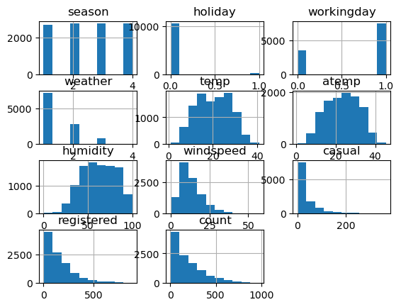

```python
# Create a histogram of all features to show the distribution of each one relative to the data. This is part of the exploritory data analysis
train.hist()
```

```python
train['datetime'] = pd.to_datetime(train['datetime'], format='%Y-%m-%d %H:%M:%S')
test['datetime'] = pd.to_datetime(test['datetime'], format='%Y-%m-%d %H:%M:%S')
```

```python
# create a new feature
train.loc[:, "datetime"] = pd.to_datetime(train.loc[:, "datetime"])
test.loc[:, "datetime"] = pd.to_datetime(test.loc[:, "datetime"])

test['year'] = test['datetime'].dt.year
test['month'] = test['datetime'].dt.month
test['day'] = test['datetime'].dt.day
test['hour'] = test['datetime'].dt.hour

train['year'] = test['datetime'].dt.year
train['month'] = test['datetime'].dt.month
train['day'] = test['datetime'].dt.day
train['hour'] = test['datetime'].dt.hour
```

## Make category types for these so models know they are not just numbers

- AutoGluon originally sees these as ints, but in reality they are int representations of a category.
- Setting the dtype to category will classify these as categories in AutoGluon.

```python
train["season"] = train["season"].astype("category")
train["weather"] = train["weather"].astype("category")
test["season"] = test["season"].astype("category")
test["weather"] = test["weather"].astype("category")
```

```python
# View are new feature
train.head()
```

|  | datetime | season | holiday | workingday | weather | temp | atemp | humidity | windspeed | casual | registered | count | year | month | day | hour |
| --- | --- | --- | --- | --- | --- | --- | --- | --- | --- | --- | --- | --- | --- | --- | --- | --- |
| 0 | 2011-01-01 00:00:00 | 1 | 0 | 0 | 1 | 9.84 | 14.395 | 81 | 0.0 | 3 | 13 | 16 | 2011.0 | 1.0 | 20.0 | 0.0 |
| 1 | 2011-01-01 01:00:00 | 1 | 0 | 0 | 1 | 9.02 | 13.635 | 80 | 0.0 | 8 | 32 | 40 | 2011.0 | 1.0 | 20.0 | 1.0 |
| 2 | 2011-01-01 02:00:00 | 1 | 0 | 0 | 1 | 9.02 | 13.635 | 80 | 0.0 | 5 | 27 | 32 | 2011.0 | 1.0 | 20.0 | 2.0 |
| 3 | 2011-01-01 03:00:00 | 1 | 0 | 0 | 1 | 9.84 | 14.395 | 75 | 0.0 | 3 | 10 | 13 | 2011.0 | 1.0 | 20.0 | 3.0 |
| 4 | 2011-01-01 04:00:00 | 1 | 0 | 0 | 1 | 9.84 | 14.395 | 75 | 0.0 | 0 | 1 | 1 | 2011.0 | 1.0 | 20.0 | 4.0 |

```
array([[<Axes: title={'center': 'datetime'}>,
        <Axes: title={'center': 'holiday'}>,
        <Axes: title={'center': 'workingday'}>,
        <Axes: title={'center': 'temp'}>],
       [<Axes: title={'center': 'atemp'}>,
        <Axes: title={'center': 'humidity'}>,
        <Axes: title={'center': 'windspeed'}>,
        <Axes: title={'center': 'casual'}>],
       [<Axes: title={'center': 'registered'}>,
        <Axes: title={'center': 'count'}>,
        <Axes: title={'center': 'year'}>,
        <Axes: title={'center': 'month'}>],
       [<Axes: title={'center': 'day'}>,
        <Axes: title={'center': 'hour'}>, <Axes: >, <Axes: >]],
      dtype=object)
```

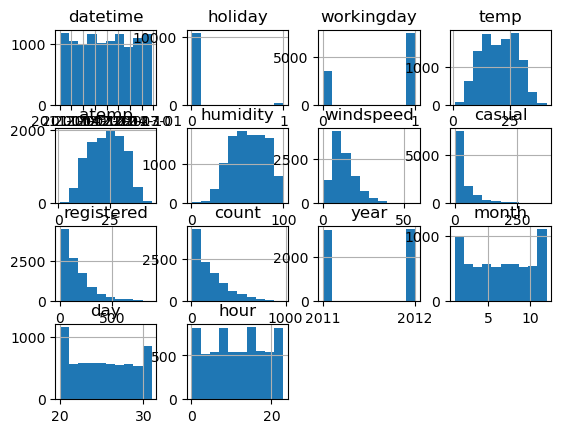

```python
# View histogram of all features again now with the hour feature
train.hist()
```

## Step 5: Rerun the model with the same settings as before, just with more features

```python
predictor_new_features = TabularPredictor(
    label = 'count',
    problem_type = "regression",
    eval_metric = "rmse").fit(
    train_data=train.drop(['casual', 'registered'], axis=1),

    time_limit = 600,
    presets = "best_quality",
    )
```

```
No path specified. Models will be saved in: "AutogluonModels/ag-20240425_142744"
Presets specified: ['best_quality']
Stack configuration (auto_stack=True): num_stack_levels=1, num_bag_folds=8, num_bag_sets=20
Beginning AutoGluon training ... Time limit = 600s
AutoGluon will save models to "AutogluonModels/ag-20240425_142744"
AutoGluon Version:  0.8.2
Python Version:     3.10.14
Operating System:   Linux
Platform Machine:   x86_64
Platform Version:   #1 SMP Sat Mar 23 09:49:55 UTC 2024
Disk Space Avail:   30.45 GB / 32.20 GB (94.6%)
Train Data Rows:    10886
Train Data Columns: 13
Label Column: count
Preprocessing data ...
Using Feature Generators to preprocess the data ...
Fitting AutoMLPipelineFeatureGenerator...
	Available Memory:                    1726.41 MB
	Train Data (Original)  Memory Usage: 0.98 MB (0.1% of available memory)
	Inferring data type of each feature based on column values. Set feature_metadata_in to manually specify special dtypes of the features.
	Stage 1 Generators:
		Fitting AsTypeFeatureGenerator...
			Note: Converting 2 features to boolean dtype as they only contain 2 unique values.
	Stage 2 Generators:
		Fitting FillNaFeatureGenerator...
	Stage 3 Generators:
		Fitting IdentityFeatureGenerator...
		Fitting CategoryFeatureGenerator...
			Fitting CategoryMemoryMinimizeFeatureGenerator...
		Fitting DatetimeFeatureGenerator...
	Stage 4 Generators:
		Fitting DropUniqueFeatureGenerator...
	Stage 5 Generators:
		Fitting DropDuplicatesFeatureGenerator...
	Types of features in original data (raw dtype, special dtypes):
		('category', []) : 2 | ['season', 'weather']
		('datetime', []) : 1 | ['datetime']
		('float', [])    : 7 | ['temp', 'atemp', 'windspeed', 'year', 'month', ...]
		('int', [])      : 3 | ['holiday', 'workingday', 'humidity']
	Types of features in processed data (raw dtype, special dtypes):
```

[output cut: 561 more lines]

```
Repeating k-fold bagging: 13/20
Repeating k-fold bagging: 14/20
Repeating k-fold bagging: 15/20
Repeating k-fold bagging: 16/20
Repeating k-fold bagging: 17/20
Repeating k-fold bagging: 18/20
Repeating k-fold bagging: 19/20
Repeating k-fold bagging: 20/20
Completed 20/20 k-fold bagging repeats ...
Fitting model: WeightedEnsemble_L3 ... Training model for up to 360.0s of the 527.87s of remaining time.
	-51.859	 = Validation score   (-root_mean_squared_error)
	0.13s	 = Training   runtime
	0.0s	 = Validation runtime
AutoGluon training complete, total runtime = 72.29s ... Best model: "WeightedEnsemble_L3"
TabularPredictor saved. To load, use: predictor = TabularPredictor.load("AutogluonModels/ag-20240425_142744")
```

```python
predictor_new_features.fit_summary()
```

```
*** Summary of fit() ***
Estimated performance of each model:
                    model   score_val  pred_time_val   fit_time  pred_time_val_marginal  fit_time_marginal  stack_level  can_infer  fit_order
0     WeightedEnsemble_L3  -51.859046       2.452739  67.275497                0.000506           0.134141            3       True          8
1  RandomForestMSE_BAG_L2  -52.502191       1.864149  56.255903                0.613335          30.767107            2       True          6
2    ExtraTreesMSE_BAG_L2  -53.028942       1.838898  36.374249                0.588084          10.885453            2       True          7
3     WeightedEnsemble_L2  -83.884423       0.665730  17.520066                0.000507           0.200055            2       True          5
4   KNeighborsDist_BAG_L1  -84.125061       0.056171   0.037974                0.056171           0.037974            1       True          2
5   KNeighborsUnif_BAG_L1 -101.546199       0.058269   0.037050                0.058269           0.037050            1       True          1
6  RandomForestMSE_BAG_L1 -104.347668       0.609052  17.282037                0.609052          17.282037            1       True          3
7    ExtraTreesMSE_BAG_L1 -110.879166       0.527321   8.131735                0.527321           8.131735            1       True          4
Number of models trained: 8
Types of models trained:
{'StackerEnsembleModel_RF', 'StackerEnsembleModel_XT', 'WeightedEnsembleModel', 'StackerEnsembleModel_KNN'}
Bagging used: True  (with 8 folds)
Multi-layer stack-ensembling used: True  (with 3 levels)
Feature Metadata (Processed):
(raw dtype, special dtypes):
('category', [])             : 2 | ['season', 'weather']
('float', [])                : 7 | ['temp', 'atemp', 'windspeed', 'year', 'month', ...]
('int', [])                  : 1 | ['humidity']
('int', ['bool'])            : 2 | ['holiday', 'workingday']
('int', ['datetime_as_int']) : 5 | ['datetime', 'datetime.year', 'datetime.month', 'datetime.day', 'datetime.dayofweek']
*** End of fit() summary ***
```

[output not shown]

[output cut: 55 more lines]

```
 3                0.000507           0.200055            2       True
 4                0.056171           0.037974            1       True
 5                0.058269           0.037050            1       True
 6                0.609052          17.282037            1       True
 7                0.527321           8.131735            1       True

    fit_order
 0          8
 1          6
 2          7
 3          5
 4          2
 5          1
 6          3
 7          4  }
```

```python
predictions_new_features = predictor_new_features.predict(test)
predictions_new_features = {'datetime': test['datetime'], 'Pred_count': predictions_new_features}
predictions_new_features = pd.DataFrame(data=predictions_new_features)
predictions_new_features.head()
```

|  | datetime | Pred_count |
| --- | --- | --- |
| 0 | 2011-01-20 00:00:00 | 32.094749 |
| 1 | 2011-01-20 01:00:00 | 48.519165 |
| 2 | 2011-01-20 02:00:00 | 52.381748 |
| 3 | 2011-01-20 03:00:00 | 54.424831 |
| 4 | 2011-01-20 04:00:00 | 56.476753 |

```python
# Remember to set all negative values to zero
predictions_new_features[predictions_new_features['Pred_count']<0] = 0
```

```python
# Same submitting predictions
submission_new_features = pd.read_csv('submission.csv')
submission_new_features["count"] = predictions_new_features['Pred_count']
submission_new_features.to_csv("submission_new_features.csv", index=False)
```

```python
!kaggle competitions submit -c bike-sharing-demand -f submission_new_features.csv -m "model2"
```

```
Successfully submitted to Bike Sharing Demand
```

```python
!kaggle competitions submissions -c bike-sharing-demand | tail -n +1 | head -n 6
```

```
fileName                     date                 description           status    publicScore  privateScore
---------------------------  -------------------  --------------------  --------  -----------  ------------
submission_new_features.csv  2024-04-25 14:29:38  model2                complete  1.68645      1.68645
submission.csv               2024-04-25 14:26:05  model1                complete  1.84007      1.84007
submission_new_features.csv  2024-04-24 14:47:40  model2                complete  1.84672      1.84672
submission.csv               2024-04-24 14:23:12  model1                complete  1.84007      1.84007
```

## Step 6: Hyper parameter optimization

- There are many options for hyper parameter optimization.
- Options are to change the AutoGluon higher level parameters or the individual model hyperparameters.
- The hyperparameters of the models themselves that are in AutoGluon. Those need the `hyperparameter` and `hyperparameter_tune_kwargs` arguments.

```python
search_strategy = 'auto'  # tune hyperparameters using Bayesian optimization routine with a local scheduler

hyperparameter_tune_kwargs = {

    'scheduler' : 'local',
    'searcher': search_strategy,
}
predictor_new_hpo = TabularPredictor(
    label = 'count',
    problem_type = "regression",
    eval_metric = "root_mean_squared_error").fit(
    train_data = train,
    time_limit = 600,
    presets = "best_quality",
    hyperparameters = 'multimodal',
    hyperparameter_tune_kwargs=hyperparameter_tune_kwargs)
```

```
No path specified. Models will be saved in: "AutogluonModels/ag-20240425_155144"
Presets specified: ['best_quality']
Warning: hyperparameter tuning is currently experimental and may cause the process to hang.
Stack configuration (auto_stack=True): num_stack_levels=1, num_bag_folds=8, num_bag_sets=20
Beginning AutoGluon training ... Time limit = 600s
AutoGluon will save models to "AutogluonModels/ag-20240425_155144"
AutoGluon Version:  0.8.2
Python Version:     3.10.14
Operating System:   Linux
Platform Machine:   x86_64
Platform Version:   #1 SMP Sat Mar 23 09:49:55 UTC 2024
Disk Space Avail:   27.99 GB / 32.20 GB (86.9%)
Train Data Rows:    10886
Train Data Columns: 15
Label Column: count
Preprocessing data ...
Using Feature Generators to preprocess the data ...
Fitting AutoMLPipelineFeatureGenerator...
	Available Memory:                    1508.07 MB
	Train Data (Original)  Memory Usage: 1.15 MB (0.1% of available memory)
	Inferring data type of each feature based on column values. Set feature_metadata_in to manually specify special dtypes of the features.
	Stage 1 Generators:
		Fitting AsTypeFeatureGenerator...
			Note: Converting 2 features to boolean dtype as they only contain 2 unique values.
	Stage 2 Generators:
		Fitting FillNaFeatureGenerator...
	Stage 3 Generators:
		Fitting IdentityFeatureGenerator...
		Fitting CategoryFeatureGenerator...
			Fitting CategoryMemoryMinimizeFeatureGenerator...
		Fitting DatetimeFeatureGenerator...
	Stage 4 Generators:
		Fitting DropUniqueFeatureGenerator...
	Stage 5 Generators:
		Fitting DropDuplicatesFeatureGenerator...
	Types of features in original data (raw dtype, special dtypes):
		('category', []) : 2 | ['season', 'weather']
		('datetime', []) : 1 | ['datetime']
		('float', [])    : 7 | ['temp', 'atemp', 'windspeed', 'year', 'month', ...]
		('int', [])      : 5 | ['holiday', 'workingday', 'humidity', 'casual', 'registered']
```

[output cut: 18053 more lines]

[output not shown]

```python
predictor_new_hpo.fit_summary()
```

```
*** Summary of fit() ***
Estimated performance of each model:
                    model   score_val  pred_time_val   fit_time  pred_time_val_marginal  fit_time_marginal  stack_level  can_infer  fit_order
0     WeightedEnsemble_L3   -2.257957       0.002282  68.488723                0.000969           0.171634            3       True          8
1    ExtraTreesMSE_BAG_L2   -2.261163       0.001063  42.380894                0.000208          10.012034            2       True          7
2  RandomForestMSE_BAG_L2   -2.361183       0.001105  58.305056                0.000251          25.936195            2       True          6
3     WeightedEnsemble_L2   -2.414602       0.001196  32.318413                0.000614           0.210323            2       True          5
4    ExtraTreesMSE_BAG_L1   -2.534672       0.000335  10.729772                0.000335          10.729772            1       True          4
5  RandomForestMSE_BAG_L1   -2.829111       0.000247  21.378317                0.000247          21.378317            1       True          3
6   KNeighborsDist_BAG_L1  -84.125061       0.000159   0.138509                0.000159           0.138509            1       True          2
7   KNeighborsUnif_BAG_L1 -101.546199       0.000114   0.122262                0.000114           0.122262            1       True          1
Number of models trained: 8
Types of models trained:
{'StackerEnsembleModel_RF', 'StackerEnsembleModel_XT', 'WeightedEnsembleModel', 'StackerEnsembleModel_KNN'}
Bagging used: True  (with 8 folds)
Multi-layer stack-ensembling used: True  (with 3 levels)
Feature Metadata (Processed):
(raw dtype, special dtypes):
('category', [])             : 2 | ['season', 'weather']
('float', [])                : 7 | ['temp', 'atemp', 'windspeed', 'year', 'month', ...]
('int', [])                  : 3 | ['humidity', 'casual', 'registered']
('int', ['bool'])            : 2 | ['holiday', 'workingday']
('int', ['datetime_as_int']) : 5 | ['datetime', 'datetime.year', 'datetime.month', 'datetime.day', 'datetime.dayofweek']
*** End of fit() summary ***
```

[output not shown]

[output cut: 55 more lines]

```
 3                0.000614           0.210323            2       True
 4                0.000335          10.729772            1       True
 5                0.000247          21.378317            1       True
 6                0.000159           0.138509            1       True
 7                0.000114           0.122262            1       True

    fit_order
 0          8
 1          7
 2          6
 3          5
 4          4
 5          3
 6          2
 7          1  }
```

```python
# Remember to set all negative values to zero
predictions_new_features[predictions_new_features['Pred_count']<0] = 0
```

```python
import numpy as np
# Same submitting predictions
submission_new_hpo['count'] = submission_new_hpo['count'].fillna(0).astype(int)
submission_new_hpo['count'] = submission_new_hpo['count'].astype(np.int64)
submission_new_hpo.to_csv("submission_new_hpo.csv", index=False)
```

[output not shown]

[output not shown]

```python
!kaggle competitions submit -c bike-sharing-demand -f submission_new_hpo.csv -m "model3"
```

```
Successfully submitted to Bike Sharing Demand
```

```python
!kaggle competitions submissions -c bike-sharing-demand | tail -n +1 | head -n 6
```

```
fileName                     date                 description           status    publicScore  privateScore
---------------------------  -------------------  --------------------  --------  -----------  ------------
submission_new_hpo.csv       2024-04-25 16:02:14  model3                complete  1.85872      1.85872
submission_new_hpo.csv       2024-04-25 15:15:37  model3                complete  1.85872      1.85872
submission_new_hpo.csv       2024-04-25 15:02:34  model3                complete  1.85872      1.85872
submission_new_features.csv  2024-04-25 14:29:38  model2                complete  1.68645      1.68645
```